# Practica ML 2

Forecasting

# Introducción

- **Descripción:** en este notebook se van a aplicar los modelos de series temporales estudiados durante el máster sobre un conjunto de datos longitudinales a elección del grupo de trabajo.
- **Datos:** los datos usados para este ejercicio contienen información de los accidentes de tráfico producidos en la ciudad de Madrid entre los años 2010 y 2020. Los ficheros de 2010 a 2018 solo registran los accidentes con heridos o con daños al patrimonio municipal.
- **Enlace a los datos:** Accidentes de tráfico en la Ciudad de Madrid
- **Grupo:** Verónica Gómez, Carlos Grande y Pablo Olmos.

# Librerías usadas

- plyr
- dplyr
- tidyr
- readxl
- forecast
- ggplot2
- stats
- zoo
- seasonal

```r
library(plyr)
library(dplyr)
library(tidyr)
library(readxl)
library(forecast)
library(ggplot2)
library(stats)
library(zoo)
library(seasonal)
```

# 1. Datos

## 1.1 Importación de datos hasta 2018

Para la importación de los datos vamos a usar una dos funciones que nos permitan la lectura y concatenación de cada uno de los archivos excel descargados del portal de datos abiertos.

```r
readr <- function(sufix){
  pth <- paste('../data/', sufix, '_Accidentalidad.xlsx', sep = '')
  df <- read_excel(pth)
  return(df)
}

concatr <- function(dfs){
  merged <- do.call(rbind, dfs)
  return(merged)
  }
```

A continuación podemos ver la tabla final con un total de 252.998 implicados, uno por cada fila del dataframe.

```r
dfs <- list()
years <- c(seq(2010, 2018))
for (year in years) {
  print(sprintf("The year %s has been processed", year))
  df <- readr(year)
  names(df)[20] <- "Nº VICTIMAS *"
  dfs[[as.character(year)]] <- df
}
```

```
[1] "The year 2010 has been processed"
[1] "The year 2011 has been processed"
[1] "The year 2012 has been processed"
[1] "The year 2013 has been processed"
[1] "The year 2014 has been processed"
[1] "The year 2015 has been processed"
[1] "The year 2016 has been processed"
[1] "The year 2017 has been processed"
[1] "The year 2018 has been processed"
```

```r
df_merged <- concatr(dfs)
head(df_merged)
```

| FECHA | RANGO HORARIO | DIA SEMANA | DISTRITO | LUGAR ACCIDENTE | Nº | Nº PARTE | CPFA Granizo | CPFA Hielo | CPFA Lluvia | CPFA Niebla | CPFA Seco | CPFA Nieve | CPSV Mojada | CPSV Aceite | CPSV Barro | CPSV Grava Suelta | CPSV Hielo | CPSV Seca Y Limpia | Nº VICTIMAS * | TIPO ACCIDENTE | Tipo Vehiculo | TIPO PERSONA | SEXO | LESIVIDAD | Tramo Edad |
| --- | --- | --- | --- | --- | --- | --- | --- | --- | --- | --- | --- | --- | --- | --- | --- | --- | --- | --- | --- | --- | --- | --- | --- | --- | --- |
| 2010-01-01 | DE 00:00 A 00:59 | VIERNES | CHAMARTIN | CALLE DE CARTAGENA NUM | 104 | 2010/135 | NO | NO | SI | NO | NO | NO | SI | NO | NO | NO | NO | NO | 1 | COLISIÓN DOBLE | TURISMO | CONDUCTOR | HOMBRE | IL | DE 18 A 20 AÑOS |
| 2010-01-01 | DE 00:00 A 00:59 | VIERNES | CHAMARTIN | CALLE DE CARTAGENA NUM | 104 | 2010/135 | NO | NO | SI | NO | NO | NO | SI | NO | NO | NO | NO | NO | 1 | COLISIÓN DOBLE | TURISMO | CONDUCTOR | HOMBRE | IL | DE 50 A 54 AÑOS |
| 2010-01-01 | DE 00:00 A 00:59 | VIERNES | CHAMARTIN | CALLE DE CARTAGENA NUM | 104 | 2010/135 | NO | NO | SI | NO | NO | NO | SI | NO | NO | NO | NO | NO | 1 | COLISIÓN DOBLE | TURISMO | VIAJERO | MUJER | HL | DE 40 A 44 AÑOS |
| 2010-01-01 | DE 1:00 A 1:59 | VIERNES | PUENTE DE VALLECAS | AUTOVIA M-30 CALZADA 2 KM. | 10200 | 2010/94 | NO | NO | NO | NO | SI | NO | SI | NO | NO | NO | NO | NO | 7 | COLISIÓN MÚLTIPLE | NO ASIGNADO | VIAJERO | MUJER | HL | DE 25 A 29 AÑOS |
| 2010-01-01 | DE 1:00 A 1:59 | VIERNES | PUENTE DE VALLECAS | AUTOVIA M-30 CALZADA 2 KM. | 10200 | 2010/94 | NO | NO | NO | NO | SI | NO | SI | NO | NO | NO | NO | NO | 7 | COLISIÓN MÚLTIPLE | NO ASIGNADO | VIAJERO | MUJER | HL | DE 30 A 34 ANOS |
| 2010-01-01 | DE 1:00 A 1:59 | VIERNES | PUENTE DE VALLECAS | AUTOVIA M-30 CALZADA 2 KM. | 10200 | 2010/94 | NO | NO | NO | NO | SI | NO | SI | NO | NO | NO | NO | NO | 7 | COLISIÓN MÚLTIPLE | NO ASIGNADO | VIAJERO | MUJER | HL | DE 25 A 29 AÑOS |

En este paso simplemente guardamos la tabla como fichero RDA y volvemos a cargarla para asegurarnos de su correcto guardado. Así evitamos volver a realizar la operación de concatenación de excels para la correcta ejecución del notebook.

```r
# save(df_merged, file = '../data/df_merged.rda')
load('../data/df_merged.rda')
head(df_merged)
```

| FECHA | RANGO HORARIO | DIA SEMANA | DISTRITO | LUGAR ACCIDENTE | Nº | Nº PARTE | CPFA Granizo | CPFA Hielo | CPFA Lluvia | CPFA Niebla | CPFA Seco | CPFA Nieve | CPSV Mojada | CPSV Aceite | CPSV Barro | CPSV Grava Suelta | CPSV Hielo | CPSV Seca Y Limpia | Nº VICTIMAS * | TIPO ACCIDENTE | Tipo Vehiculo | TIPO PERSONA | SEXO | LESIVIDAD | Tramo Edad |
| --- | --- | --- | --- | --- | --- | --- | --- | --- | --- | --- | --- | --- | --- | --- | --- | --- | --- | --- | --- | --- | --- | --- | --- | --- | --- |
| 2010-01-01 | DE 00:00 A 00:59 | VIERNES | CHAMARTIN | CALLE DE CARTAGENA NUM | 104 | 2010/135 | NO | NO | SI | NO | NO | NO | SI | NO | NO | NO | NO | NO | 1 | COLISIÓN DOBLE | TURISMO | CONDUCTOR | HOMBRE | IL | DE 18 A 20 AÑOS |
| 2010-01-01 | DE 00:00 A 00:59 | VIERNES | CHAMARTIN | CALLE DE CARTAGENA NUM | 104 | 2010/135 | NO | NO | SI | NO | NO | NO | SI | NO | NO | NO | NO | NO | 1 | COLISIÓN DOBLE | TURISMO | CONDUCTOR | HOMBRE | IL | DE 50 A 54 AÑOS |
| 2010-01-01 | DE 00:00 A 00:59 | VIERNES | CHAMARTIN | CALLE DE CARTAGENA NUM | 104 | 2010/135 | NO | NO | SI | NO | NO | NO | SI | NO | NO | NO | NO | NO | 1 | COLISIÓN DOBLE | TURISMO | VIAJERO | MUJER | HL | DE 40 A 44 AÑOS |
| 2010-01-01 | DE 1:00 A 1:59 | VIERNES | PUENTE DE VALLECAS | AUTOVIA M-30 CALZADA 2 KM. | 10200 | 2010/94 | NO | NO | NO | NO | SI | NO | SI | NO | NO | NO | NO | NO | 7 | COLISIÓN MÚLTIPLE | NO ASIGNADO | VIAJERO | MUJER | HL | DE 25 A 29 AÑOS |
| 2010-01-01 | DE 1:00 A 1:59 | VIERNES | PUENTE DE VALLECAS | AUTOVIA M-30 CALZADA 2 KM. | 10200 | 2010/94 | NO | NO | NO | NO | SI | NO | SI | NO | NO | NO | NO | NO | 7 | COLISIÓN MÚLTIPLE | NO ASIGNADO | VIAJERO | MUJER | HL | DE 30 A 34 ANOS |
| 2010-01-01 | DE 1:00 A 1:59 | VIERNES | PUENTE DE VALLECAS | AUTOVIA M-30 CALZADA 2 KM. | 10200 | 2010/94 | NO | NO | NO | NO | SI | NO | SI | NO | NO | NO | NO | NO | 7 | COLISIÓN MÚLTIPLE | NO ASIGNADO | VIAJERO | MUJER | HL | DE 25 A 29 AÑOS |

## 1.2 Estudio de variables de 2010/18

Los datos consisten en un total de 26 variables para cada uno de los implicados en un accidente.

```r
df_merged %>% str()
```

```
tibble [252,998 × 26] (S3: tbl_df/tbl/data.frame)
 $ FECHA             : POSIXct[1:252998], format: "2010-01-01" "2010-01-01" "2010-01-01" "2010-01-01" ...
 $ RANGO HORARIO     : chr [1:252998] "DE 00:00 A 00:59" "DE 00:00 A 00:59" "DE 00:00 A 00:59" "DE 1:00 A 1:59" ...
 $ DIA SEMANA        : chr [1:252998] "VIERNES" "VIERNES" "VIERNES" "VIERNES" ...
 $ DISTRITO          : chr [1:252998] "CHAMARTIN" "CHAMARTIN" "CHAMARTIN" "PUENTE DE VALLECAS" ...
 $ LUGAR ACCIDENTE   : chr [1:252998] "CALLE DE CARTAGENA NUM" "CALLE DE CARTAGENA NUM" "CALLE DE CARTAGENA NUM" "AUTOVIA  M-30 CALZADA 2 KM." ...
 $ Nº                : num [1:252998] 104 104 104 10200 10200 10200 10200 10200 10200 10200 ...
 $ Nº PARTE          : chr [1:252998] "2010/135" "2010/135" "2010/135" "2010/94" ...
 $ CPFA Granizo      : chr [1:252998] "NO" "NO" "NO" "NO" ...
 $ CPFA Hielo        : chr [1:252998] "NO" "NO" "NO" "NO" ...
 $ CPFA Lluvia       : chr [1:252998] "SI" "SI" "SI" "NO" ...
 $ CPFA Niebla       : chr [1:252998] "NO" "NO" "NO" "NO" ...
 $ CPFA Seco         : chr [1:252998] "NO" "NO" "NO" "SI" ...
 $ CPFA Nieve        : chr [1:252998] "NO" "NO" "NO" "NO" ...
 $ CPSV Mojada       : chr [1:252998] "SI" "SI" "SI" "SI" ...
 $ CPSV Aceite       : chr [1:252998] "NO" "NO" "NO" "NO" ...
 $ CPSV Barro        : chr [1:252998] "NO" "NO" "NO" "NO" ...
 $ CPSV Grava Suelta : chr [1:252998] "NO" "NO" "NO" "NO" ...
 $ CPSV Hielo        : chr [1:252998] "NO" "NO" "NO" "NO" ...
 $ CPSV Seca Y Limpia: chr [1:252998] "NO" "NO" "NO" "NO" ...
 $ Nº VICTIMAS *     : num [1:252998] 1 1 1 7 7 7 7 7 7 7 ...
 $ TIPO ACCIDENTE    : chr [1:252998] "COLISIÓN DOBLE" "COLISIÓN DOBLE" "COLISIÓN DOBLE" "COLISIÓN MÚLTIPLE" ...
 $ Tipo Vehiculo     : chr [1:252998] "TURISMO" "TURISMO" "TURISMO" "NO ASIGNADO" ...
 $ TIPO PERSONA      : chr [1:252998] "CONDUCTOR" "CONDUCTOR" "VIAJERO" "VIAJERO" ...
 $ SEXO              : chr [1:252998] "HOMBRE" "HOMBRE" "MUJER" "MUJER" ...
 $ LESIVIDAD         : chr [1:252998] "IL" "IL" "HL" "HL" ...
 $ Tramo Edad        : chr [1:252998] "DE 18 A 20 AÑOS" "DE 50 A 54 AÑOS" "DE 40 A 44 AÑOS" "DE 25 A 29 AÑOS" ...
```

# 2. Limpieza de los datos

## 2.1 Renombrado de variables

```r
df_merged <- df_merged %>% rename('fecha' = 'FECHA',
                     'rango_horario' = 'RANGO HORARIO',
                     'dia_semana' = 'DIA SEMANA',
                     'distrito' = 'DISTRITO',
                     'lugar_accidente' = 'LUGAR ACCIDENTE',
                     'n_calle' = 'Nº',
                     'parte_accidente' = 'Nº PARTE',
                     'granizo' = 'CPFA Granizo',
                     'hielo' = 'CPFA Hielo',
                     'lluvia' = 'CPFA Lluvia',
                     'niebla' = 'CPFA Niebla',
                     'seco' = 'CPFA Seco',
                     'nieve' = 'CPFA Nieve',
                     'via_mojada' = 'CPSV Mojada',
                     'via_aceite' = 'CPSV Aceite',
                     'via_barro' = 'CPSV Barro',
                     'via_grava' = 'CPSV Grava Suelta',
                     'via_hielo' = 'CPSV Hielo',
                     'via_seca' = 'CPSV Seca Y Limpia',
                     'n_victimas' = 'Nº VICTIMAS *',
                     'accidente' = 'TIPO ACCIDENTE',
                     'vehiculo' = 'Tipo Vehiculo',
                     'persona' = 'TIPO PERSONA',
                     'sexo' = 'SEXO',
                     'lesividad' = 'LESIVIDAD',
                     'tramo_edad' = 'Tramo Edad'
                     )
head(df_merged)
```

| fecha | rango_horario | dia_semana | distrito | lugar_accidente | n_calle | parte_accidente | granizo | hielo | lluvia | niebla | seco | nieve | via_mojada | via_aceite | via_barro | via_grava | via_hielo | via_seca | n_victimas | accidente | vehiculo | persona | sexo | lesividad | tramo_edad |
| --- | --- | --- | --- | --- | --- | --- | --- | --- | --- | --- | --- | --- | --- | --- | --- | --- | --- | --- | --- | --- | --- | --- | --- | --- | --- |
| 2010-01-01 | DE 00:00 A 00:59 | VIERNES | CHAMARTIN | CALLE DE CARTAGENA NUM | 104 | 2010/135 | NO | NO | SI | NO | NO | NO | SI | NO | NO | NO | NO | NO | 1 | COLISIÓN DOBLE | TURISMO | CONDUCTOR | HOMBRE | IL | DE 18 A 20 AÑOS |
| 2010-01-01 | DE 00:00 A 00:59 | VIERNES | CHAMARTIN | CALLE DE CARTAGENA NUM | 104 | 2010/135 | NO | NO | SI | NO | NO | NO | SI | NO | NO | NO | NO | NO | 1 | COLISIÓN DOBLE | TURISMO | CONDUCTOR | HOMBRE | IL | DE 50 A 54 AÑOS |
| 2010-01-01 | DE 00:00 A 00:59 | VIERNES | CHAMARTIN | CALLE DE CARTAGENA NUM | 104 | 2010/135 | NO | NO | SI | NO | NO | NO | SI | NO | NO | NO | NO | NO | 1 | COLISIÓN DOBLE | TURISMO | VIAJERO | MUJER | HL | DE 40 A 44 AÑOS |
| 2010-01-01 | DE 1:00 A 1:59 | VIERNES | PUENTE DE VALLECAS | AUTOVIA M-30 CALZADA 2 KM. | 10200 | 2010/94 | NO | NO | NO | NO | SI | NO | SI | NO | NO | NO | NO | NO | 7 | COLISIÓN MÚLTIPLE | NO ASIGNADO | VIAJERO | MUJER | HL | DE 25 A 29 AÑOS |
| 2010-01-01 | DE 1:00 A 1:59 | VIERNES | PUENTE DE VALLECAS | AUTOVIA M-30 CALZADA 2 KM. | 10200 | 2010/94 | NO | NO | NO | NO | SI | NO | SI | NO | NO | NO | NO | NO | 7 | COLISIÓN MÚLTIPLE | NO ASIGNADO | VIAJERO | MUJER | HL | DE 30 A 34 ANOS |
| 2010-01-01 | DE 1:00 A 1:59 | VIERNES | PUENTE DE VALLECAS | AUTOVIA M-30 CALZADA 2 KM. | 10200 | 2010/94 | NO | NO | NO | NO | SI | NO | SI | NO | NO | NO | NO | NO | 7 | COLISIÓN MÚLTIPLE | NO ASIGNADO | VIAJERO | MUJER | HL | DE 25 A 29 AÑOS |

## 2.2 Transformación de variables

### Variable fecha

```r
 df_merged[['fecha']] <- df_merged[['fecha']] %>% as.Date(., '%Y-%m-%d')
head(df_merged)
```

| fecha | rango_horario | dia_semana | distrito | lugar_accidente | n_calle | parte_accidente | granizo | hielo | lluvia | niebla | seco | nieve | via_mojada | via_aceite | via_barro | via_grava | via_hielo | via_seca | n_victimas | accidente | vehiculo | persona | sexo | lesividad | tramo_edad |
| --- | --- | --- | --- | --- | --- | --- | --- | --- | --- | --- | --- | --- | --- | --- | --- | --- | --- | --- | --- | --- | --- | --- | --- | --- | --- |
| 2010-01-01 | DE 00:00 A 00:59 | VIERNES | CHAMARTIN | CALLE DE CARTAGENA NUM | 104 | 2010/135 | NO | NO | SI | NO | NO | NO | SI | NO | NO | NO | NO | NO | 1 | COLISIÓN DOBLE | TURISMO | CONDUCTOR | HOMBRE | IL | DE 18 A 20 AÑOS |
| 2010-01-01 | DE 00:00 A 00:59 | VIERNES | CHAMARTIN | CALLE DE CARTAGENA NUM | 104 | 2010/135 | NO | NO | SI | NO | NO | NO | SI | NO | NO | NO | NO | NO | 1 | COLISIÓN DOBLE | TURISMO | CONDUCTOR | HOMBRE | IL | DE 50 A 54 AÑOS |
| 2010-01-01 | DE 00:00 A 00:59 | VIERNES | CHAMARTIN | CALLE DE CARTAGENA NUM | 104 | 2010/135 | NO | NO | SI | NO | NO | NO | SI | NO | NO | NO | NO | NO | 1 | COLISIÓN DOBLE | TURISMO | VIAJERO | MUJER | HL | DE 40 A 44 AÑOS |
| 2010-01-01 | DE 1:00 A 1:59 | VIERNES | PUENTE DE VALLECAS | AUTOVIA M-30 CALZADA 2 KM. | 10200 | 2010/94 | NO | NO | NO | NO | SI | NO | SI | NO | NO | NO | NO | NO | 7 | COLISIÓN MÚLTIPLE | NO ASIGNADO | VIAJERO | MUJER | HL | DE 25 A 29 AÑOS |
| 2010-01-01 | DE 1:00 A 1:59 | VIERNES | PUENTE DE VALLECAS | AUTOVIA M-30 CALZADA 2 KM. | 10200 | 2010/94 | NO | NO | NO | NO | SI | NO | SI | NO | NO | NO | NO | NO | 7 | COLISIÓN MÚLTIPLE | NO ASIGNADO | VIAJERO | MUJER | HL | DE 30 A 34 ANOS |
| 2010-01-01 | DE 1:00 A 1:59 | VIERNES | PUENTE DE VALLECAS | AUTOVIA M-30 CALZADA 2 KM. | 10200 | 2010/94 | NO | NO | NO | NO | SI | NO | SI | NO | NO | NO | NO | NO | 7 | COLISIÓN MÚLTIPLE | NO ASIGNADO | VIAJERO | MUJER | HL | DE 25 A 29 AÑOS |

### Variables dummy

```r
df_merged$granizo <- df_merged$granizo %>% revalue(c('NO' = 0, 'SI' = 1)) %>% as.factor()
df_merged$hielo <- df_merged$hielo %>% revalue(c('NO' = 0, 'SI' = 1)) %>% as.factor()
df_merged$lluvia <- df_merged$lluvia %>% revalue(c('NO' = 0, 'SI' = 1)) %>% as.factor()
df_merged$niebla <- df_merged$niebla %>% revalue(c('NO' = 0, 'SI' = 1)) %>% as.factor()
df_merged$seco <- df_merged$seco %>% revalue(c('NO' = 0, 'SI' = 1)) %>% as.factor()
df_merged$nieve <- df_merged$nieve %>% revalue(c('NO' = 0, 'SI' = 1)) %>% as.factor()
df_merged$via_mojada <- df_merged$via_mojada %>% revalue(c('NO' = 0, 'SI' = 1)) %>% as.factor()
df_merged$via_aceite <- df_merged$via_aceite %>% revalue(c('NO' = 0, 'SI' = 1)) %>% as.factor()
df_merged$via_barro <- df_merged$via_barro %>% revalue(c('NO' = 0, 'SI' = 1)) %>% as.factor()
df_merged$via_grava <- df_merged$via_grava %>% revalue(c('NO' = 0, 'SI' = 1)) %>% as.factor()
df_merged$via_hielo <- df_merged$via_hielo %>% revalue(c('NO' = 0, 'SI' = 1)) %>% as.factor()
df_merged$via_seca <- df_merged$via_seca %>% revalue(c('NO' = 0, 'SI' = 1)) %>% as.factor()


selected <- c("granizo", "hielo", "lluvia", "niebla", "seco", "nieve", "via_mojada", "via_aceite", "via_barro", "via_grava", "via_hielo", "via_seca")
df_merged %>% select(selected) %>% str()
```

```
tibble [252,998 × 12] (S3: tbl_df/tbl/data.frame)
 $ granizo   : Factor w/ 2 levels "0","1": 1 1 1 1 1 1 1 1 1 1 ...
 $ hielo     : Factor w/ 2 levels "0","1": 1 1 1 1 1 1 1 1 1 1 ...
 $ lluvia    : Factor w/ 2 levels "0","1": 2 2 2 1 1 1 1 1 1 1 ...
 $ niebla    : Factor w/ 2 levels "0","1": 1 1 1 1 1 1 1 1 1 1 ...
 $ seco      : Factor w/ 2 levels "0","1": 1 1 1 2 2 2 2 2 2 2 ...
 $ nieve     : Factor w/ 2 levels "0","1": 1 1 1 1 1 1 1 1 1 1 ...
 $ via_mojada: Factor w/ 2 levels "0","1": 2 2 2 2 2 2 2 2 2 2 ...
 $ via_aceite: Factor w/ 2 levels "0","1": 1 1 1 1 1 1 1 1 1 1 ...
 $ via_barro : Factor w/ 2 levels "0","1": 1 1 1 1 1 1 1 1 1 1 ...
 $ via_grava : Factor w/ 2 levels "0","1": 1 1 1 1 1 1 1 1 1 1 ...
 $ via_hielo : Factor w/ 2 levels "0","1": 1 1 1 1 1 1 1 1 1 1 ...
 $ via_seca  : Factor w/ 2 levels "0","1": 1 1 1 1 1 1 1 1 1 1 ...
```

### Variable lesividad

En los datos anteriores a 2019 la lesividad tiene 5 niveles que renombraremos de esta manera:

- *ileso*: sin daños.
- *leve*: ingreso inferior a 24 horas.
- *grave*: ingreso superior a 24 horas.
- *fallecido*: fallecido 24 horas
- *nd*: no definido

```r
df_merged$lesividad <- df_merged$lesividad %>% revalue(c('IL' = 'ileso',
                                'HL' = 'leve',
                                'HG' = 'grave',
                                'MT' = 'fallecido',
                                'NO ASIGNADA' = 'nd')) %>% as.factor()

df_merged %>% select('lesividad') %>% str()
```

```
tibble [252,998 × 1] (S3: tbl_df/tbl/data.frame)
 $ lesividad: Factor w/ 5 levels "fallecido","grave",..: 3 3 4 4 4 4 4 3 4 4 ...
```

### Variables a factores

En el siguiente paso vamos a realizar la conversión de todas las variables categóricas a factores.

```r
df_merged$dia_semana <-  df_merged$dia_semana %>% as.factor()
df_merged$distrito <- df_merged$distrito %>% as.factor()
df_merged$accidente <- df_merged$accidente %>% as.factor()
df_merged$vehiculo <- df_merged$vehiculo %>% as.factor()
df_merged$persona <- df_merged$persona %>% as.factor()
df_merged$sexo <- df_merged$sexo %>% as.factor()
df_merged$lesividad <- df_merged$lesividad %>% as.factor()
df_merged$tramo_edad <- df_merged$tramo_edad %>% as.factor()
```

## 2.3 Selección de variables

Dado que en esta tabla aparece una fila por cada implicado en un accidente y a nosotros lo que nos interesa es una tabla con un accidente por cada fila con sus parámetros asociados, vamos a realizar una selección de las variables que más nos interesan. Fijándonos en la tabla podemos ver que las únicas variables que varían para cada parte de accidente son: - vehículo: dado que en un accidente puede haber varios vehículos implicados. - Persona: ya que puede ser viajero, conductor, peatón… - Sexo: de cada implicado. - lesividad: mantendremos la lesividad del accidente como lesividad general cogiendo siempre la más grave del conjunto. - tramo_edad: depende de cada implicado no del conjunto.

De esta manera eliminaremos cada una de estas variables salvo la variable de lesividad que la mantendremos como única.

* La variable *n_victimas* se repite por cada parte de accidente, siendo una suma total de todos los afectados en ese accidente por lo que dejaremos la variable intacta.

Por el momento tampoco seleccionaremos las variables del entorno o la vía. Por lo que finalmente nos quedaremos con las siguientes variables.

```r
df_accidentes <- df_merged %>% select(1:4, 7, 20:21) %>% group_by(parte_accidente) %>% unique()
df_fallecidos <- df_merged %>%
  select(c(parte_accidente, lesividad)) %>% filter(lesividad == 'fallecido') %>%
  group_by(parte_accidente) %>%
  summarise(n_fallecidos = n())
df_accidentes <- join(df_accidentes, df_fallecidos, by='parte_accidente', type='left')
df_accidentes$n_fallecidos <- df_accidentes$n_fallecidos %>% replace_na(0)

head(df_accidentes)
```

| fecha | rango_horario | dia_semana | distrito | parte_accidente | n_victimas | accidente | n_fallecidos |
| --- | --- | --- | --- | --- | --- | --- | --- |
| 2010-01-01 | DE 00:00 A 00:59 | VIERNES | CHAMARTIN | 2010/135 | 1 | COLISIÓN DOBLE | 0 |
| 2010-01-01 | DE 1:00 A 1:59 | VIERNES | PUENTE DE VALLECAS | 2010/94 | 7 | COLISIÓN MÚLTIPLE | 0 |
| 2010-01-01 | DE 2:00 A 2:59 | VIERNES | CHAMBERI | 2010/7 | 1 | COLISIÓN DOBLE | 0 |
| 2010-01-01 | DE 4:00 A 4:59 | VIERNES | RETIRO | 2010/4 | 7 | COLISIÓN MÚLTIPLE | 0 |
| 2010-01-01 | DE 5:00 A 5:59 | VIERNES | SALAMANCA | 2010/172 | 1 | COLISIÓN DOBLE | 0 |
| 2010-01-01 | DE 8:00 A 8:59 | VIERNES | CARABANCHEL | 2010/6 | 2 | CHOQUE CON OBJETO FIJO | 0 |

### Estructura de los datos

```r
df_accidentes %>% summary()
```

```
     fecha            rango_horario          dia_semana             distrito     parte_accidente      n_victimas
 Min.   :2010-01-01   Length:86817       DOMINGO  : 8441   SALAMANCA    : 6627   Length:86817       Min.   : 1.000
 1st Qu.:2012-05-26   Class :character   JUEVES   :13714   CHAMARTIN    : 6391   Class :character   1st Qu.: 1.000
 Median :2014-10-12   Mode  :character   LUNES    :12836   CENTRO       : 6256   Mode  :character   Median : 1.000
 Mean   :2014-08-31                      MARTES   :13395   CIUDAD LINEAL: 5554                      Mean   : 1.288
 3rd Qu.:2016-12-10                      MIERCOLES:13716   CHAMBERI     : 5156                      3rd Qu.: 1.000
 Max.   :2018-12-31                      SABADO   : 9785   CARABANCHEL  : 5154                      Max.   :22.000
                                         VIERNES  :14930   (Other)      :51679
                  accidente      n_fallecidos
 COLISIÓN DOBLE        :48001   Min.   :0.000000
 ATROPELLO             :13671   1st Qu.:0.000000
 CAÍDA MOTOCICLETA     : 8358   Median :0.000000
 COLISIÓN MÚLTIPLE     : 6384   Mean   :0.003168
 CHOQUE CON OBJETO FIJO: 5217   3rd Qu.:0.000000
 CAÍDA BICICLETA       : 1778   Max.   :2.000000
 (Other)               : 3408
```

# 3. Análisis exploratorio

En este primer apartado vamos a explorar los diferentes factores que afectan a la temporalidad y estudiar las correlaciónes que se producen.

## 3.1 Selección de variables temporales

```r
df_ts <- df_accidentes %>% mutate(meses = format(fecha, '%Y-%m')) %>%
  group_by(meses) %>%
  summarise(fecha = first(fecha), n_accidentes = n(), n_victimas = sum(n_victimas), n_fallecidos = sum(n_fallecidos)) %>%
  arrange((fecha))
head(df_ts, 10)
```

| meses | fecha | n_accidentes | n_victimas | n_fallecidos |
| --- | --- | --- | --- | --- |
| 2010-01 | 2010-01-01 | 613 | 815 | 2 |
| 2010-02 | 2010-02-01 | 685 | 890 | 4 |
| 2010-03 | 2010-03-01 | 747 | 1025 | 5 |
| 2010-04 | 2010-04-01 | 696 | 909 | 0 |
| 2010-05 | 2010-05-01 | 858 | 1121 | 2 |
| 2010-06 | 2010-06-01 | 851 | 1147 | 4 |
| 2010-07 | 2010-07-01 | 767 | 966 | 1 |
| 2010-08 | 2010-08-01 | 509 | 695 | 4 |
| 2010-09 | 2010-09-01 | 679 | 911 | 3 |
| 2010-10 | 2010-10-01 | 864 | 1145 | 2 |

## 3.2 Estudio de la temporalidad

En este primer apartado se puede ver como existe un fuerte patrón que se repite con una frecuencia aparente de 12 meses.

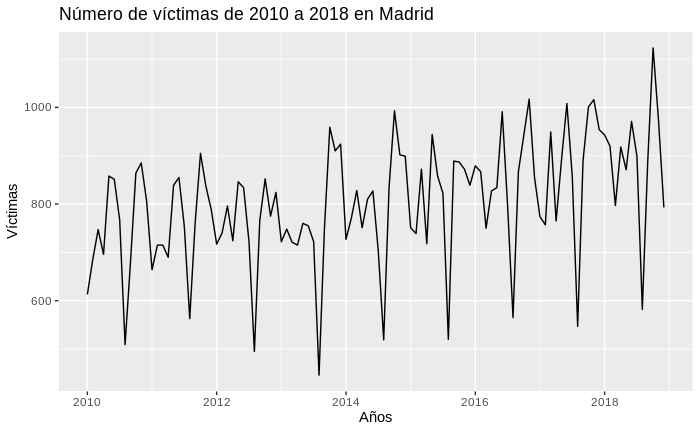

```r
# plot the data using ggplot2 and pipes
ts_accidentes <- ts(df_ts$n_accidentes,
           start = c(2010, 1),
           end = c(2018, 12),
           frequency = 12)

autoplot(ts_accidentes) +
  ggtitle('Número de víctimas de 2010 a 2018 en Madrid') +
  xlab('Años') + ylab('Víctimas')
```

Una forma de comprobar si existe realmente un patrón anual es generar un plot con la distribución superpuesta de cada uno de los años registrados. En esta gráfica se puede afirmar que efectivamente existe un patrón anual muy fuerte.

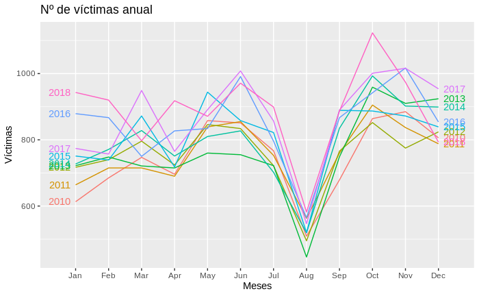

```r
ggseasonplot(ts_accidentes, year.labels = T, year.labels.left = T) + xlab('Meses') + ylab('Víctimas') + ggtitle('Nº de víctimas anual')
```

## 3.3 Estacionalidad y tendencia

En este apartado para asegurarnos de que el patrón se repite con una frecuencia de 12 meses vamos a realizar un gráfico con la función de autocorrelación. Comprobamos que la correlación más alta se da cada 12 meses

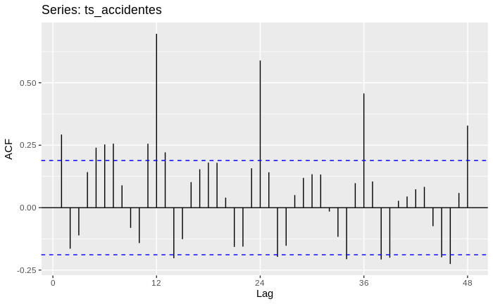

```r
ggAcf(ts_accidentes, lag.max = 48)
```

Con este plot podemos observar que existe una estacionalidad ya que se repiten patrones cada cierto tiempo pero también puede verse una tendencia al reducirse las correlaciones al aumentar el lag de tiempo.

Para poder ver mejor la tendencia y estacionalidad en cada caso podemos mostrar un diagrama de descomposición de factores, usando STL como método de descomosición. Este método es versatil y robusto, permitiendo estimar relaciones no lineales.

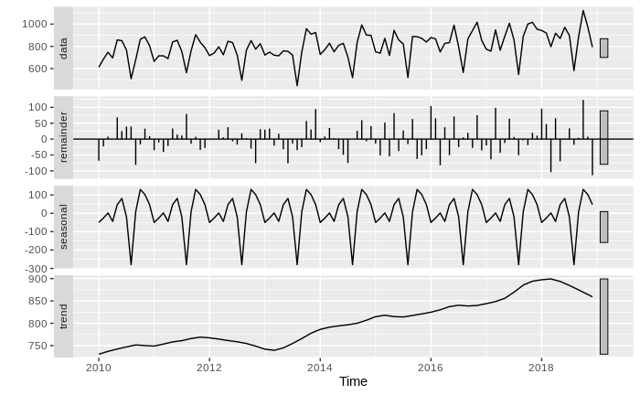

```r
stl <- ts_accidentes %>% stl(s.window="periodic", robust=TRUE)
stl %>% autoplot()
```

Podemos ver como hay una tendencia general en el aumento de accidentes desde 2010 y una fuerte estacionalidad anual.

Por otro lado vamos a representar esta tendencia de aumento sobre la serie completa junto con la variación de la estacionalidad a lo largo de la serie.

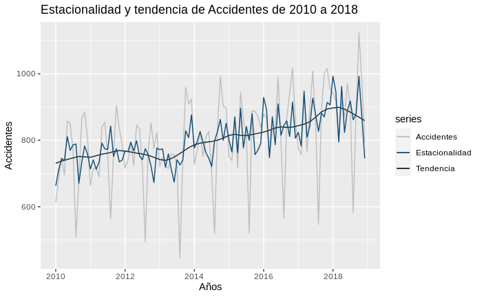

```r
autoplot(ts_accidentes, series="Accidentes") +
  autolayer(trendcycle(stl), series="Tendencia") +
  autolayer(seasadj(stl), series="Estacionalidad") +
  xlab("Años") + ylab("Accidentes") +
  ggtitle("Estacionalidad y tendencia de Accidentes de 2010 a 2018") +
  scale_color_manual(values = c('gray', '#0f4c75', '#1b262c'))
```

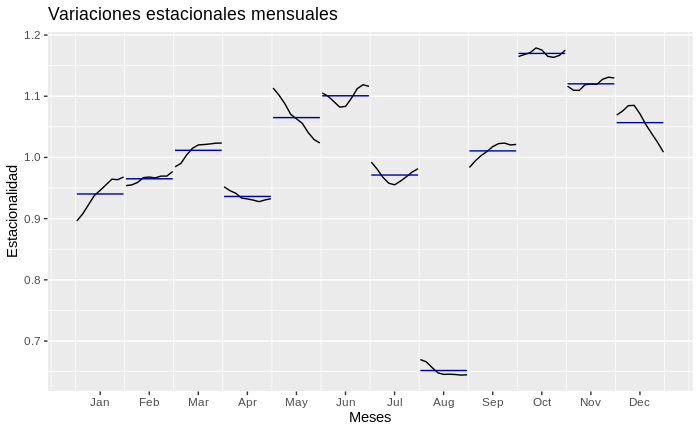

```r
ts_accidentes %>% seas() %>% seasonal() %>% ggsubseriesplot() + xlab("Meses") + ylab("Estacionalidad") + ggtitle("Variaciones estacionales mensuales")
```

# 4 Naive forecasting

Una primera aproximación a la predicción puede realizarse de manera sencilla con los siguientes métodos:

- Media: esta predicción asume que la media de todos los valores futuros debe ser igual a la de los históricos.
- Naive: esta predicción asume que los valores futuros son iguales al último valor conocido.
- Naive estacionario: este predicción asume que los valores futuros son iguales a los históricos que coincidan en el mismo periodo temporal pasado.

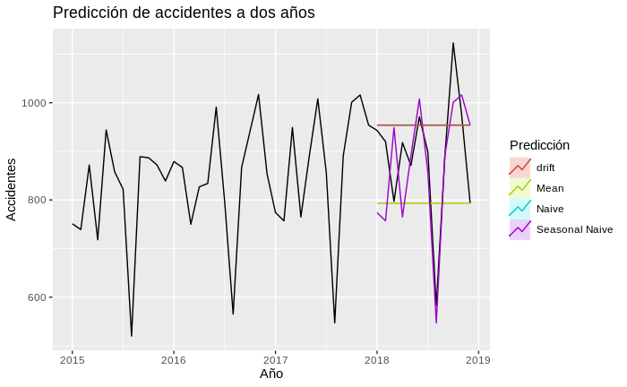

```r
train <- window(ts_accidentes, start=2010, end=c(2017, 12))
train_avg <- meanf(train, h=12)
train_naive <- rwf(train, h=12)
train_snaive <- snaive(train, h=12)
train_drift <- rwf(train, h=12)

autoplot(window(ts_accidentes, start=2015)) +
  autolayer(train_avg, series = "Mean", PI = F) +
  autolayer(train_naive, series = "Naive", PI = F) +
  autolayer(train_snaive, series = "Seasonal Naive", PI = F) +
  autolayer(train_drift, series = "drift", PI = F) +
  xlab("Año") + ylab("Accidentes") +
  ggtitle("Predicción de accidentes a dos años") +
  guides(colour=guide_legend(title = "Predicción"));
```

```r
NA
NA
```

Podemos comprobar los errores de los tres modelos en Train, si nos fijamos en el error MAPE el más bajo de los tres es obviamente el Seasonal Naive.

```r
test <- window(ts_accidentes, start = 2017)
rbind(accuracy(train_avg), accuracy(train_naive), accuracy(train_snaive), accuracy(train_drift))
```

```
                        ME      RMSE       MAE       MPE      MAPE     MASE        ACF1
Training set -3.791036e-14 119.86224  93.88064 -2.736329 12.954331 1.713225  0.26592530
Training set  3.589474e+00 143.87813 111.16842 -1.602582 15.047872 2.028709 -0.18497550
Training set  1.725000e+01  69.30102  54.79762  1.754507  6.797124 1.000000 -0.06698821
Training set  3.589474e+00 143.87813 111.16842 -1.602582 15.047872 2.028709 -0.18497550
```

Podemos ver el error del modelo Naive estacional contra test con los siguientes estadísticos:

```r
train_snaive %>% forecast(h = 12) %>% accuracy(ts_accidentes)
```

```
                   ME      RMSE      MAE      MPE      MAPE     MASE        ACF1 Theil's U
Training set 17.25000  69.30102 54.79762 1.754507  6.797124 1.000000 -0.06698821        NA
Test set     22.41667 111.42224 91.58333 1.976978 10.332180 1.671301 -0.19640063 0.5020142
```

Durante está práctica nos vamos a fijar principalemente en el error MAPE, ya que es una medida en series temporales que indica la precisión del modelo como un porcentaje y funciona bien si no hay valores extremos o iguales a 0.

En este caso podemos ver como el modelo **Seasonal Naive** tiene un error MAPE en test de un **10.3%**. Esta cifra nos ayudará para compararla con el error de los modelos posteriores.

# 5 Seasonal ARIMA model

Para datos con estacionalidad podemos aplicar el modelo ARIMA incluyendo términos estacionales añadiendo una componente que depende del numero de observaciones por año.

## 5.1 ARIMA manual

En primer lugar vamos a representar los gráficos de Autocorrelación y Autocorrelación parcial como ya hemos hecho anteriormente para confirmar la correlación de datos en el lag 12.

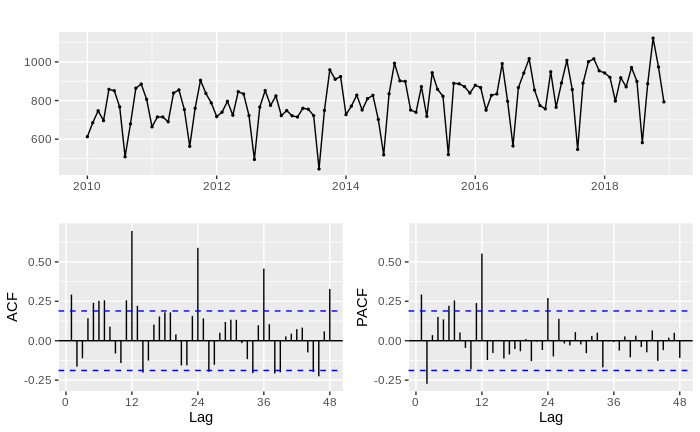

```r
ts_accidentes %>% ggtsdisplay(lag.max = 48)
```

Para comenzar una primera aproximación de los parametros p, d, q estacionarios podemos restar el lag de la serie así misma varias veces hasta que los datos empiecen a parecer estacionarios. De esta manera podemos observar los correlogramas y estimar un modelo candidato, este proceso lo usaremos solo como análisis sin aplicar las transformaciones en la variable principal.

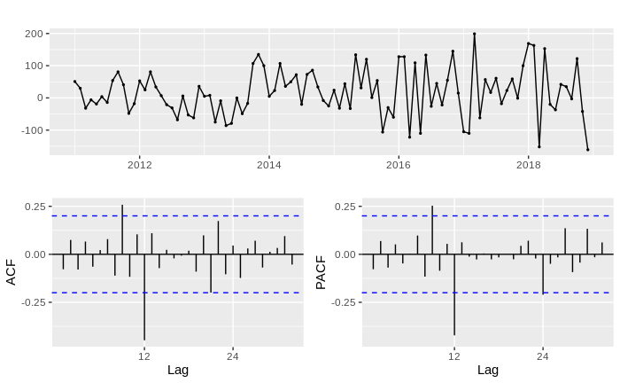

```r
ts_accidentes %>% diff(lag=12) %>% ggtsdisplay()
```

```r
#ARIMA(0,0,0)(0,1,1)
```

```r
non_sns <- c(2,0,0)
sns <- c(0,1,1)

ts_train <- window(ts_accidentes, end = c(2018))
arima_train <- Arima(ts_train, order = non_sns, seasonal = sns)
arima_train
```

```
Series: ts_train
ARIMA(2,0,0)(0,1,1)[12]

Coefficients:
        ar1     ar2     sma1
      0.237  0.3305  -0.5949
s.e.  0.114  0.1175   0.1284

sigma^2 estimated as 3786:  log likelihood=-472.03
AIC=952.06   AICc=952.56   BIC=961.83
```

```r
arima_train %>% forecast(h = 12) %>% accuracy(ts_accidentes)
```

```
                   ME     RMSE      MAE      MPE     MAPE      MASE       ACF1 Theil's U
Training set 13.65680 56.57118 41.08886 1.330888 5.034288 0.7318845 -0.0713153        NA
Test set     20.03358 84.52603 67.68712 1.728020 7.662458 1.2056592 -0.3450961 0.3984809
```

```
    Ljung-Box test

data:  Residuals from ARIMA(2,0,0)(0,1,1)[12]
Q* = 16.162, df = 16, p-value = 0.4417

Model df: 3.   Total lags used: 19
```

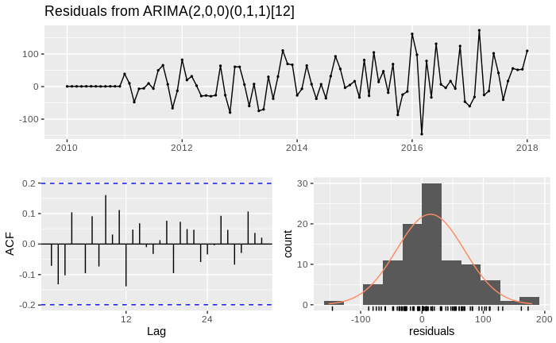

```r
checkresiduals(arima_train)
```

Realizamos la predicción a 12 meses comprobando su gráfica.

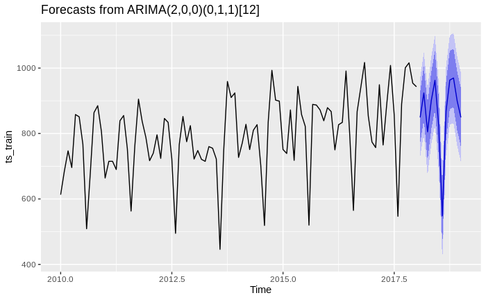

```r
arima_train %>% forecast(h = 12) %>% autoplot()
```

Por otro lado podemos ver que el error MAPE es de un **7.6%** casi un 3% menor que en el Seasonal Naive, esto indica que vamos por buen camino.

```r
arima_train %>% forecast(h = 12) %>% accuracy(ts_accidentes)
```

```
                   ME     RMSE      MAE      MPE     MAPE      MASE       ACF1 Theil's U
Training set 13.65680 56.57118 41.08886 1.330888 5.034288 0.7318845 -0.0713153        NA
Test set     20.03358 84.52603 67.68712 1.728020 7.662458 1.2056592 -0.3450961 0.3984809
```

## 5.2 ARIMA autoajustado

Aunque no se aprecia una varianza inestable vamos a aplicar una transformación de Box-Cox y comprobar si nos beneficia de alguna manera esta transformación.

```r
lambda <- BoxCox.lambda(ts_train,lower=0)
lambda
```

```
[1] 4.102259e-05
```

Como el valor lambda es muy próximo a cero, se puede transformar mediante un logaritmo natural. Puesto que no afecta al resultado, además es una transformación más simple, como se observa a continuación.

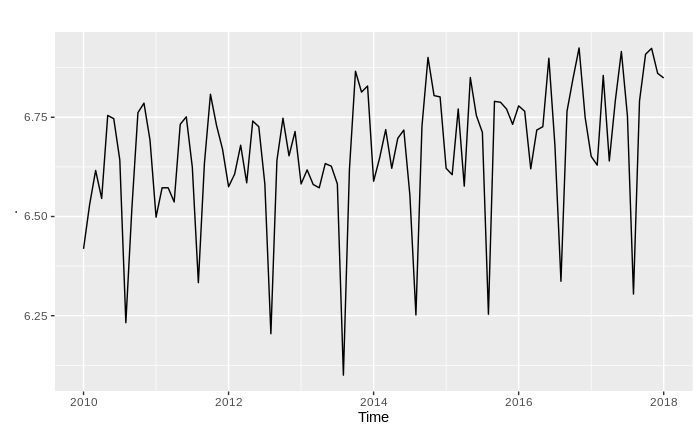

```r
ts_boxcox <- log(ts_train)
ts_boxcox %>% autoplot()
```

En este caso vamos a probar a ajustar los parámetros del Arima de manera automática desactivando algunos atajos de cálculo y aproximación para asegurarnos de que encuentra el mejor resultado.

```r
arima_train_auto <- auto.arima(ts_train, stepwise=F, approximation=F)
arima_train_auto
```

```
Series: ts_train
ARIMA(0,0,0)(0,1,1)[12] with drift

Coefficients:
         sma1   drift
      -0.7613  1.5590
s.e.   0.1571  0.2143

sigma^2 estimated as 3094:  log likelihood=-466.3
AIC=938.59   AICc=938.89   BIC=945.92
```

```r
arima_train_boxcox <- auto.arima(ts_boxcox, stepwise=F, approximation=F)
arima_train_boxcox
```

```
Series: ts_boxcox
ARIMA(0,0,0)(0,1,1)[12] with drift

Coefficients:
         sma1   drift
      -0.7619  0.0019
s.e.   0.1553  0.0003

sigma^2 estimated as 0.004798:  log likelihood=102.25
AIC=-198.5   AICc=-198.2   BIC=-191.17
```

Tras realizar el ARIMA automático el modelo ha seleccionado los parámetros de (0, 0, 0) y (0, 1, 1) bastante similares a los que habíamos elegido de manera manual. A continuación comprobaremos los residuos y el Ljung-Box test que es igual a 0.7 por lo que no podemos rechazar la hipótesis de que los residuos son ruido.

```
    Ljung-Box test

data:  Residuals from ARIMA(0,0,0)(0,1,1)[12] with drift
Q* = 12.958, df = 17, p-value = 0.739

Model df: 2.   Total lags used: 19
```

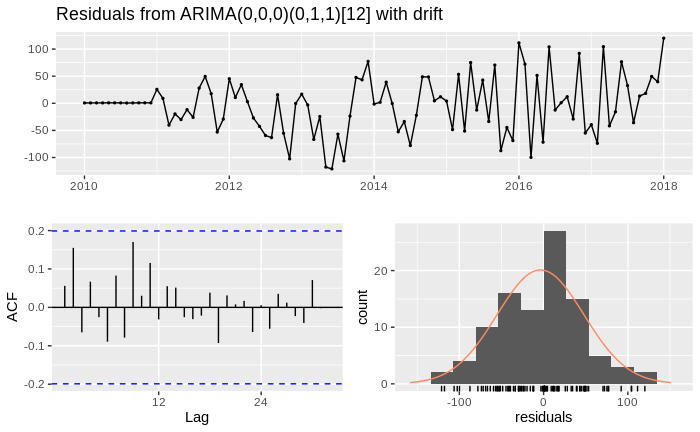

```r
checkresiduals(arima_train_auto)
```

```
    Ljung-Box test

data:  Residuals from ARIMA(0,0,0)(0,1,1)[12] with drift
Q* = 16.259, df = 20, p-value = 0.7004

Model df: 2.   Total lags used: 22
```

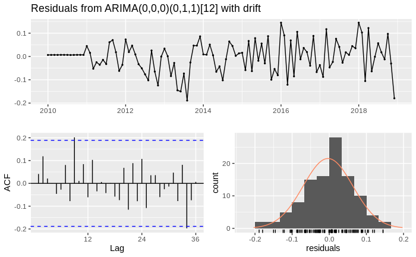

```r
checkresiduals(arima_train_boxcox)
```

Posteriormente vamos a realizar la predicción y comprobar el error obtenido contra test.

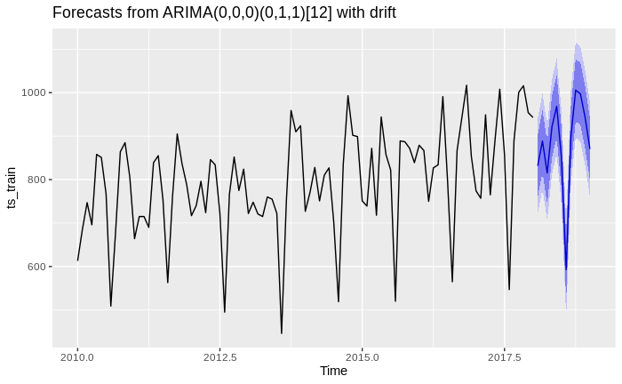

```r
arima_train_auto %>% forecast(h = 12) %>% autoplot()
```

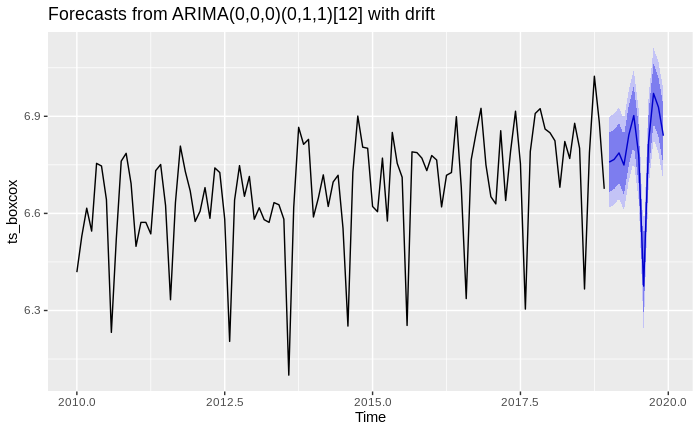

```r
arima_train_boxcox %>% forecast(h = 12) %>% autoplot()
```

En este caso conseguimos reducir el error en test a un **7.13%**, muy similar al error obtenido en el ARIMA ajustado manualmente.

```r
arima_train_auto %>% forecast(h = 12) %>% accuracy(ts_accidentes)
```

```
                    ME     RMSE      MAE        MPE     MAPE      MASE        ACF1 Theil's U
Training set -3.682873 51.44935 39.40772 -0.9503499 4.989583 0.7019397  0.05609697        NA
Test set      1.915784 78.93450 63.27683 -0.4470880 7.139048 1.1271020 -0.34848332 0.3560214
```

```r
arima_train_boxcox %>% forecast(h = 12) %>% accuracy(log(ts_accidentes))
```

```
                        ME       RMSE        MAE          MPE    MAPE      MASE        ACF1 Theil's U
Training set -0.0034965055 0.06407655 0.04963814 -0.061605331 0.74501 0.7003309  0.08580926        NA
Test set      0.0004654072 0.08956185 0.07282891 -0.003490656 1.07441 1.0275231 -0.34094776 0.3675584
```

Podemos observar como los resultados con y sin la transformación de BoxCox no generan grandes cambios en el error MAPE. Por lo que no se hace necesaria esta transformación.

# 6 Exponential Smoothing

En este apartado vamos a usar el modelo de *Exponential Smoothing* otro modelo muy generalizado ya que estos modelos solo se pueden aplicar en datos no estacionarios. Usando los mismo datos de Train y Test vamos a comenzar el entrenamiento.

```r
ets_train <- ts_train %>% ets()
ets_train
```

```
ETS(M,A,A)

Call:
 ets(y = .)

  Smoothing parameters:
    alpha = 0.1083
    beta  = 1e-04
    gamma = 1e-04

  Initial states:
    l = 732.2188
    b = 1.5583
    s = 57.8492 96.6961 126.5941 5.6117 -268.1843 -27.2041
           76.5616 52.8188 -54.1811 10.8453 -29.8813 -47.5261

  sigma:  0.0655

     AIC     AICc      BIC
1224.629 1232.376 1268.399
```

Al comprobar los residuos podemos ver como se asemejan al ruido blanco obteniendo en el ACF muy baja correlación. Aunque por otro lado el p valor da por debajo de 0.05 por lo que deberíamos rechazar la hipótesis de ruido blanco.

```
    Ljung-Box test

data:  Residuals from ETS(M,A,A)
Q* = 12.881, df = 3, p-value = 0.004901

Model df: 16.   Total lags used: 19
```

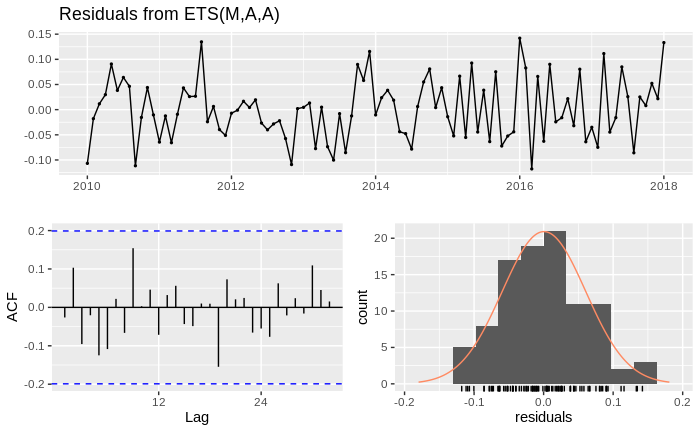

```r
checkresiduals(ets_train)
```

Vamos a predecir la parte faltante de test, obteniendo los siguientes resultados.

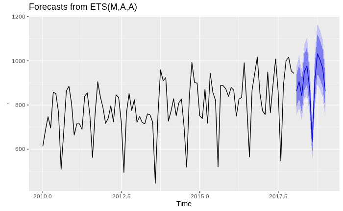

```r
ts_train %>% ets() %>% forecast(h=12) %>% autoplot()
```

Finalmente podemor ver que el error MAPE es de **7.74%**, un error muy similar al obtenido con el ARIMA.

```r
ets_train %>% forecast(h = 12) %>% accuracy(ts_accidentes)
```

```
                      ME     RMSE      MAE        MPE     MAPE     MASE        ACF1 Theil's U
Training set   0.9040142 47.92768 38.75178 -0.3029446 4.856005 0.690256 -0.02825364        NA
Test set     -20.3494431 79.96578 65.51219 -3.1413308 7.741278 1.166919 -0.34134844 0.3680882
```

## 7 Dynamic regression model

Otro modelo a probar sería de regresión dinámica, ayudándonos de otras variables con las que realizaremos una regresión lineal y que apoyarán el entrenamiento del modelo.

### Número de accidentes en función del número de dias no laborables al mes

En primer lugar vamos a utitlizar los datos del calentario laboral de la Comunidad de Madrid contando los días no laborables incluyendo festivos y fines de semana cada mes.

Se puede encontrar en este enlace: https://calendarios.ideal.es/laboral/comunidad-de-madrid/2018

```r
df_vacaciones <- read_excel('../data/2018_2018_LibresLaborables.xls')
df_vacaciones <- df_vacaciones %>% mutate(total = festivos+fines_semana)
head(df_vacaciones)
```

| meses | festivos | fines_semana | total |
| --- | --- | --- | --- |
| 01-2010 | 2 | 10 | 12 |
| 02-2010 | 0 | 8 | 8 |
| 03-2010 | 0 | 8 | 8 |
| 04-2010 | 1 | 8 | 9 |
| 05-2010 | 0 | 10 | 10 |
| 06-2010 | 0 | 8 | 8 |

En segundo lugar para asegurarnos de que existe una relación entre el número de accidenetes en Madrid y los días no laborables vamos a visualizar una gráfica de puntos con estas dos variables contrapuestas.

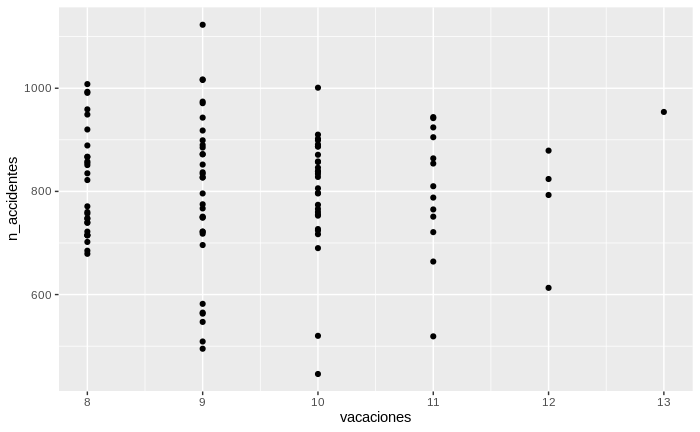

```r
df_drm <- df_ts %>% select(c(meses, n_accidentes))
df_drm['vacaciones'] <- df_vacaciones$total

ggplot(df_drm, aes(vacaciones, n_accidentes)) + geom_point()
```

Mostrada esta correlación el siguiente paso es estudiar la variación de estas dos variables a lo largo del tiempo para ver sus estacionalidad y tendencia.

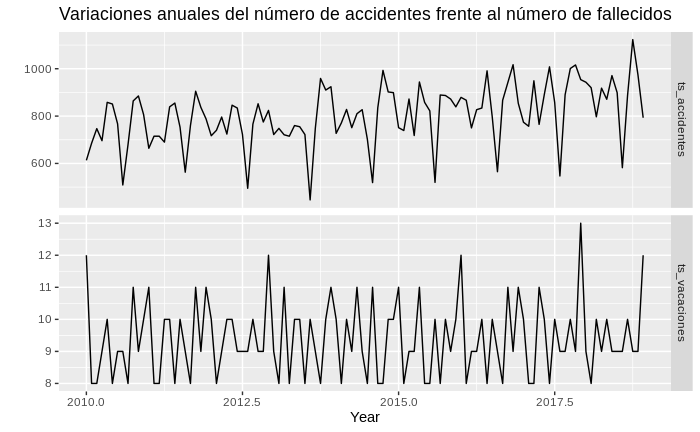

```r
# plot the data using ggplot2 and pipes
ts_vacaciones <- ts(df_vacaciones$total,
           start = c(2010, 1),
           end = c(2018, 12),
           frequency = 12)


autoplot(cbind(ts_accidentes, ts_vacaciones), facets=TRUE) +
  xlab("Year") + ylab("") +
  ggtitle("Variaciones anuales del número de accidentes frente al número de fallecidos")
```

A continuación vamos a entrenar el modelo de regresión dinámica ayudándonos de los datos de festivos y no laborables para ello vamos a usar un auto ARIMA con regresión.

```r
ts_train_fallecidos <- window(ts_vacaciones, end=c(2018))
drm_train <- auto.arima(ts_train, xreg = ts_train_fallecidos)
drm_train
```

```
Series: ts_train
Regression with ARIMA(0,0,0)(0,1,1)[12] errors

Coefficients:
         sma1   drift      xreg
      -0.8098  1.5723  -10.6208
s.e.   0.1839  0.1999    6.2554

sigma^2 estimated as 2953:  log likelihood=-464.87
AIC=937.75   AICc=938.25   BIC=947.52
```

Podemos comprobar los residuos de ambos modelos, comprobando que el modelo ARIMA tiene apariencia de ruido.

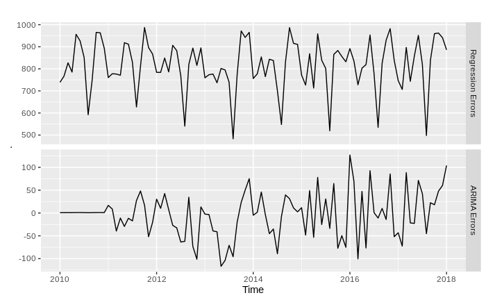

```r
cbind("Regression Errors" = residuals(drm_train, type = "regression"), "ARIMA Errors" = residuals(drm_train, type = "innovation")) %>% autoplot(facets=T)
```

Centrándonos en el ACF y en el resultado del test de Ljung-Box no podemos rechazar la hipótesis de ruido blanco en los residuos.

```
    Ljung-Box test

data:  Residuals from Regression with ARIMA(0,0,0)(0,1,1)[12] errors
Q* = 11.145, df = 16, p-value = 0.8005

Model df: 3.   Total lags used: 19
```

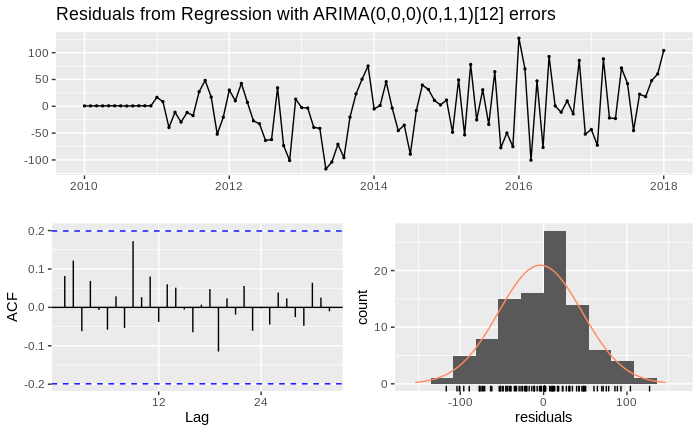

```r
checkresiduals(drm_train)
```

Finalemente vamos a realizar la predicción a un año y comparar el accuracy del modelo.

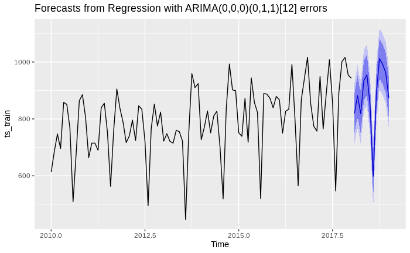

```r
fcast <- forecast(drm_train, xreg=rep(mean(ts_train_fallecidos), 12))
autoplot(fcast)
```

```r
fcast %>% accuracy(ts_accidentes)
```

```
                    ME     RMSE      MAE        MPE     MAPE      MASE        ACF1 Theil's U
Training set -3.841559 49.96161 38.27875 -0.9498936 4.847485 0.6818301  0.08175394        NA
Test set      2.370279 83.09664 66.50191 -0.4509359 7.551063 1.1845478 -0.31019110 0.3671013
```

# Referencias y enlaces

Se pueden revisar el repositorio y los datos en este enlace: https://github.com/charlstown/ForecastingAccidentsMadrid